# DEMassign1

Christopher Huong

2023-01-28

```r
library(tidyverse)
library(readxl)
library(car)
library(janitor)
library(ggplot2)
library(stargazer)
library(ggpubr)
library(ggrepel)
dat <- read_excel("Junkins Data.xlsx")
```

Load in relevant libraries and import excel data

```r
dat <- dat %>%
  mutate(south = if_else(region == 3, 1L, 0L),
         northeast = if_else(region == 1, 1L, 0L),
         midwest = if_else(region == 2, 1L, 0L),
         west = if_else(region == 4, 1L, 0L))

sum(dat$south, dat$midwest, dat$northeast, dat$west)
```

```
## [1] 50
```

Create new variables ‘south’, ‘northeast’, ‘midwest’, and ‘west’. Assign south = 1 if region = 3, else south = 0. 1L means the integer 1, rather than 1.0000… Assign northeast = 1 if region = 1, else northeast = 0 Assign midwest = 1 if region = 2, else midwest = 0 Assign west = 1 if region = 4, else west = 0

Then add the new columns to make sure they sum to 50

```r
dat <- dat %>%
  mutate(relcons2 = relcons^2,
         relcons3 = relcons^3,
         relconsln = log(relcons),
         relconsrec = relcons^-1)
```

Create new variables for transformed relcons

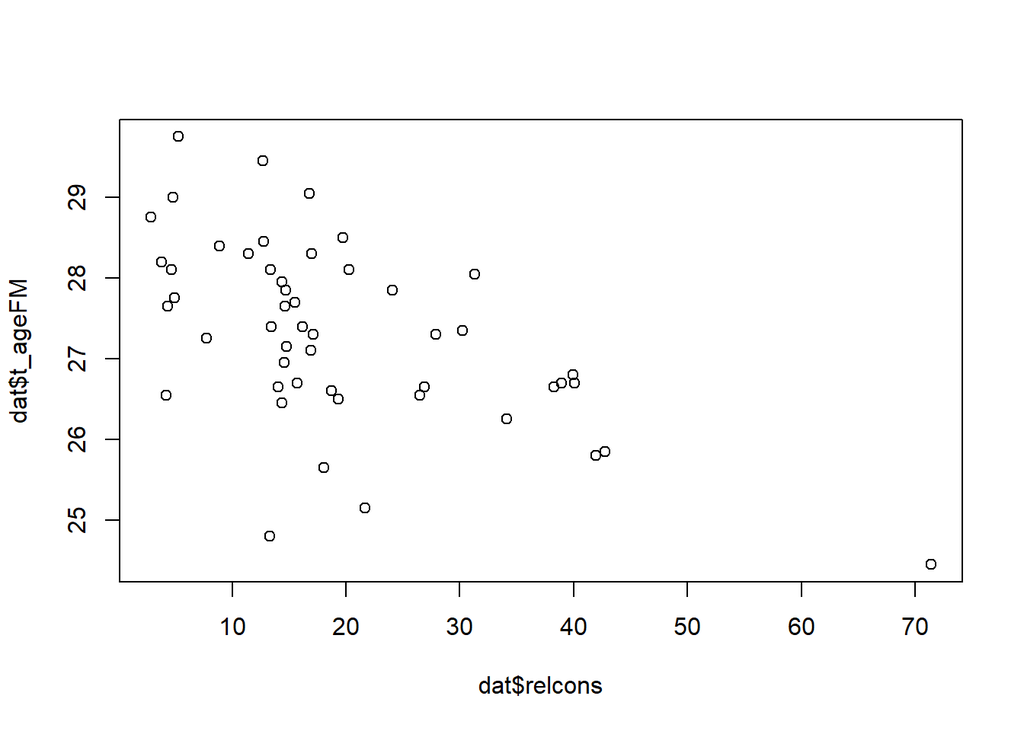

```r
plot(dat$relcons,dat$t_ageFM)
```

```r
cor.test(dat$relcons,dat$t_ageFM)
```

```
##
##  Pearson's product-moment correlation
##
## data:  dat$relcons and dat$t_ageFM
## t = -4.8748, df = 48, p-value = 1.233e-05
## alternative hypothesis: true correlation is not equal to 0
## 95 percent confidence interval:
##  -0.7359186 -0.3537616
## sample estimates:
##        cor
## -0.5754459
```

Plot the scatter plot with x = relcons, and y = t_ageFM to visualize the relationship Calculate the Pearson correlation between the variables Notice a relatively strong negative relationship, with r=-0.57 confirming this

```r
mod1 <-lm(t_ageFM ~ relcons, dat)
summary(mod1)
```

```
##
## Call:
## lm(formula = t_ageFM ~ relcons, data = dat)
##
## Residuals:
##     Min      1Q  Median      3Q     Max
## -2.8183 -0.4097  0.0782  0.5650  1.8037
##
## Coefficients:
##             Estimate Std. Error t value Pr(>|t|)
## (Intercept) 28.27091    0.23707 119.252  < 2e-16 ***
## relcons     -0.04911    0.01007  -4.875 1.23e-05 ***
## ---
## Signif. codes:  0 '***' 0.001 '**' 0.01 '*' 0.05 '.' 0.1 ' ' 1
##
## Residual standard error: 0.9335 on 48 degrees of freedom
## Multiple R-squared:  0.3311, Adjusted R-squared:  0.3172
## F-statistic: 23.76 on 1 and 48 DF,  p-value: 1.233e-05
```

Use OLS linear model to regress age of first marriage on religious conservatism The model predicts for every 1 unit increase in relcons is associated with a -0.05 unit decrease in t_ageFM. ~32% of the variance of t_ageFM is explained by relcons.

```r
mod2 <- lm(t_ageFM ~ relcons + relcons2, dat)
summary(mod2)
```

```
##
## Call:
## lm(formula = t_ageFM ~ relcons + relcons2, data = dat)
##
## Residuals:
##      Min       1Q   Median       3Q      Max
## -2.81884 -0.41111  0.08564  0.56738  1.80413
##
## Coefficients:
##               Estimate Std. Error t value Pr(>|t|)
## (Intercept)  2.824e+01  3.623e-01  77.952   <2e-16 ***
## relcons     -4.607e-02  2.878e-02  -1.601    0.116
## relcons2    -5.175e-05  4.593e-04  -0.113    0.911
## ---
## Signif. codes:  0 '***' 0.001 '**' 0.01 '*' 0.05 '.' 0.1 ' ' 1
##
## Residual standard error: 0.9432 on 47 degrees of freedom
## Multiple R-squared:  0.3313, Adjusted R-squared:  0.3029
## F-statistic: 11.64 on 2 and 47 DF,  p-value: 7.81e-05
```

Add a quadratic relcons term to the regression to model a nonlinear relationship of y and x No added variance is explained

```r
mod3 <-lm(t_ageFM~relcons + relcons2 + relcons3, dat)
summary(mod3)
```

```
##
## Call:
## lm(formula = t_ageFM ~ relcons + relcons2 + relcons3, data = dat)
##
## Residuals:
##      Min       1Q   Median       3Q      Max
## -2.74980 -0.53189  0.02847  0.54631  1.86677
##
## Coefficients:
##               Estimate Std. Error t value Pr(>|t|)
## (Intercept)  2.859e+01  5.415e-01  52.791   <2e-16 ***
## relcons     -1.017e-01  7.065e-02  -1.439    0.157
## relcons2     2.049e-03  2.481e-03   0.826    0.413
## relcons3    -2.026e-05  2.351e-05  -0.862    0.393
## ---
## Signif. codes:  0 '***' 0.001 '**' 0.01 '*' 0.05 '.' 0.1 ' ' 1
##
## Residual standard error: 0.9458 on 46 degrees of freedom
## Multiple R-squared:  0.3419, Adjusted R-squared:  0.299
## F-statistic: 7.968 on 3 and 46 DF,  p-value: 0.0002207
```

Add a quadratic and cubic term to the regression model, no added variance is explained

```r
mod4 <-lm(t_ageFM~relconsln, dat)
summary(mod4)
```

```
##
## Call:
## lm(formula = t_ageFM ~ relconsln, data = dat)
##
## Residuals:
##     Min      1Q  Median      3Q     Max
## -2.6441 -0.5908  0.0393  0.6119  1.9690
##
## Coefficients:
##             Estimate Std. Error t value Pr(>|t|)
## (Intercept)  29.6203     0.5419  54.655  < 2e-16 ***
## relconsln    -0.8412     0.1911  -4.402 5.96e-05 ***
## ---
## Signif. codes:  0 '***' 0.001 '**' 0.01 '*' 0.05 '.' 0.1 ' ' 1
##
## Residual standard error: 0.9633 on 48 degrees of freedom
## Multiple R-squared:  0.2876, Adjusted R-squared:  0.2728
## F-statistic: 19.38 on 1 and 48 DF,  p-value: 5.958e-05
```

Log-transforming the predictor, which should improve the model if the distribution of the predictor is skewed No added variance is explained

```r
mod5 <-lm(t_ageFM~relconsrec, dat)
summary(mod5)
```

```
##
## Call:
## lm(formula = t_ageFM ~ relconsrec, data = dat)
##
## Residuals:
##      Min       1Q   Median       3Q      Max
## -2.44794 -0.49354 -0.09158  0.80604  2.17950
##
## Coefficients:
##             Estimate Std. Error t value Pr(>|t|)
## (Intercept)  26.7445     0.2233 119.789  < 2e-16 ***
## relconsrec    6.6906     2.0013   3.343  0.00161 **
## ---
## Signif. codes:  0 '***' 0.001 '**' 0.01 '*' 0.05 '.' 0.1 ' ' 1
##
## Residual standard error: 1.028 on 48 degrees of freedom
## Multiple R-squared:  0.1889, Adjusted R-squared:  0.172
## F-statistic: 11.18 on 1 and 48 DF,  p-value: 0.001612
```

Taking the recipricol of the predictor No added variance is explained

```r
BIC(mod1, mod2, mod3, mod4, mod5)
```

```
##      df      BIC
## mod1  3 144.7034
## mod2  4 148.6019
## mod3  5 151.7130
## mod4  3 147.8541
## mod5  3 154.3459
```

```r
anova(mod1, mod2, mod3, mod4, mod5)
```

```
## Analysis of Variance Table
##
## Model 1: t_ageFM ~ relcons
## Model 2: t_ageFM ~ relcons + relcons2
## Model 3: t_ageFM ~ relcons + relcons2 + relcons3
## Model 4: t_ageFM ~ relconsln
## Model 5: t_ageFM ~ relconsrec
##   Res.Df    RSS Df Sum of Sq      F Pr(>F)
## 1     48 41.825
## 2     47 41.814  1    0.0113 0.0126 0.9110
## 3     46 41.149  1    0.6645 0.7428 0.3932
## 4     48 44.545 -2   -3.3962 1.8983 0.1614
## 5     48 50.721  0   -6.1758
```

Directly comparing the models.

Model 1 has the lowest BIC, indicating that the relationship between t_ageFM and relcons is best explained by a linear model

```r
mod_med <-lm(t_ageFM~northeast + relcons, dat)

summary(mod_med)
```

```
##
## Call:
## lm(formula = t_ageFM ~ northeast + relcons, data = dat)
##
## Residuals:
##      Min       1Q   Median       3Q      Max
## -2.72217 -0.50792 -0.02583  0.54625  1.90289
##
## Coefficients:
##             Estimate Std. Error t value Pr(>|t|)
## (Intercept) 28.10361    0.30729  91.457  < 2e-16 ***
## northeast    0.34786    0.40488   0.859 0.394607
## relcons     -0.04375    0.01187  -3.686 0.000589 ***
## ---
## Signif. codes:  0 '***' 0.001 '**' 0.01 '*' 0.05 '.' 0.1 ' ' 1
##
## Residual standard error: 0.936 on 47 degrees of freedom
## Multiple R-squared:  0.3415, Adjusted R-squared:  0.3135
## F-statistic: 12.19 on 2 and 47 DF,  p-value: 5.45e-05
```

Coefficient went from -0.04911 to -0.04375 and no added variance was explained, indicating that being a northeastern state does not mediate the relationship between t_ageFM and relcons

```r
mod_moder <- lm(t_ageFM~relcons*northeast, dat)
summary(mod_moder)
```

```
##
## Call:
## lm(formula = t_ageFM ~ relcons * northeast, data = dat)
##
## Residuals:
##      Min       1Q   Median       3Q      Max
## -2.72617 -0.50502 -0.02841  0.57561  1.89866
##
## Coefficients:
##                   Estimate Std. Error t value Pr(>|t|)
## (Intercept)       28.11320    0.30988  90.724  < 2e-16 ***
## relcons           -0.04417    0.01197  -3.689 0.000594 ***
## northeast         -0.23321    1.06750  -0.218 0.828031
## relcons:northeast  0.11804    0.20041   0.589 0.558754
## ---
## Signif. codes:  0 '***' 0.001 '**' 0.01 '*' 0.05 '.' 0.1 ' ' 1
##
## Residual standard error: 0.9426 on 46 degrees of freedom
## Multiple R-squared:  0.3464, Adjusted R-squared:  0.3038
## F-statistic: 8.127 on 3 and 46 DF,  p-value: 0.0001898
```

Modeling main effects of relcons and northeast, as well as their interaction The northeast:relcons term is non-significant, indicating no interaction with relcons and northeast on t_ageFM

```r
mod_a <- lm(t_ageFM~northeast, dat)
mod_b <- lm (t_ageFM~northeast + relcons, dat)

stargazer(mod_a, mod_b,type="text",
          column.labels = c("Model 1", "Model 2"),
          intercept.bottom = FALSE,
          single.row=FALSE,
          notes.append = FALSE,
          header=FALSE)
```

```
##
## ================================================================
##                                 Dependent variable:
##                     --------------------------------------------
##                                       t_ageFM
##                            Model 1               Model 2
##                              (1)                   (2)
## ----------------------------------------------------------------
## Constant                  27.107***             28.104***
##                            (0.164)               (0.307)
##
## northeast                 1.132***                0.348
##                            (0.387)               (0.405)
##
## relcons                                         -0.044***
##                                                  (0.012)
##
## ----------------------------------------------------------------
## Observations                 50                     50
## R2                          0.151                 0.341
## Adjusted R2                 0.133                 0.313
## Residual Std. Error    1.052 (df = 48)       0.936 (df = 47)
## F Statistic         8.545*** (df = 1; 48) 12.186*** (df = 2; 47)
## ================================================================
## Note:                                *p<0.1; **p<0.05; ***p<0.01
```

Pretty table